# R Notebook

#### Estudios Avanzados de Distribución

Ventana de Silverman

Métodos de Maxima verosimilitud

```r
#ventana de silverman...
h_sil1<-round((4*sd(datos$sl2l_dm)^5/3*length(datos$sl2l_dm))^(1/5),0)
h_sil2<-1.06*min(sd(datos$sl2l_dm),IQR(datos$sl2l_dm)/1.349)*length(datos$sl2l_dm)^(1/5)
h_sil2
```

```
[1] 6.268536
```

```r
h_sil1
```

```
[1] 7
```

```r
sd(datos$sl2l_dm) # Desviación estandar
```

```
[1] 2.584422
```

```r
IQR(datos$sl2l_dm)/1.349 # Desviación estandar - error estandar coincidente con distribucíón normal.
```

```
[1] 2.373592
```

```r
 h<-h_sil1
# la función density es la estimación
hist(datos$sl2l_dm, freq = FALSE,ylim=c(0,0.2))
lines(density(datos$sl2l_dm,kernel = "gaussian",width=h),col="yellowgreen",lwd=2)
```

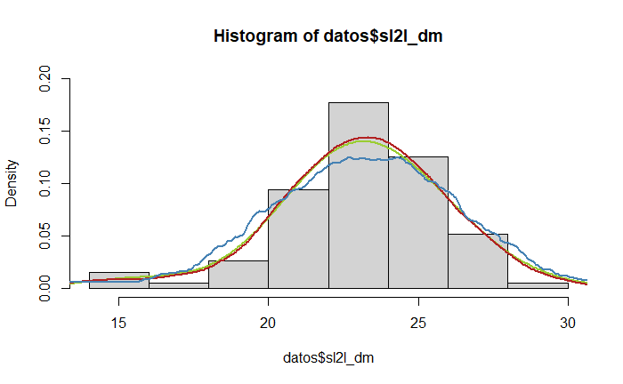

```r
lines(density(datos$sl2l_dm,kernel = "epanechnikov",width=h),col="firebrick",lwd=2)
lines(density(datos$sl2l_dm,kernel = "rectangular",width=h),col="steelblue",lwd=2)
```

```r
h<-h_sil2
# la función density es la estimación
hist(datos$sl2l_dm, freq = FALSE,ylim=c(0,0.2))
lines(density(datos$sl2l_dm,kernel = "gaussian",width=h),col="yellowgreen",lwd=2)
```

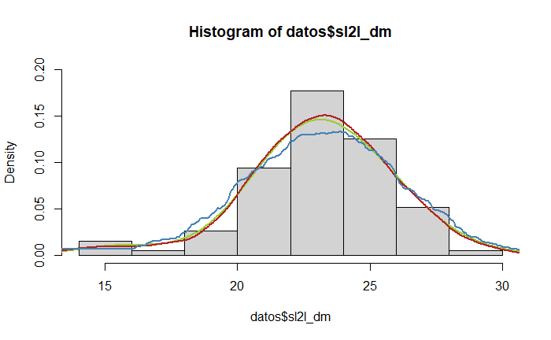

```r
lines(density(datos$sl2l_dm,kernel = "epanechnikov",width=h),col="firebrick",lwd=2)
lines(density(datos$sl2l_dm,kernel = "rectangular",width=h),col="steelblue",lwd=2)
```

```r
#--------------- VALORES AJUSTADOS DE OUTLIERS
#ventana de silverman...
h_sil3<-round((4*sd(datasinout1$sl2l_diameter)^5/3*length(datasinout1$sl2l_diameter))^(1/5),0)
h_sil4<-1.06*min(sd(datasinout1$sl2l_diameter),IQR(datasinout1$sl2l_diameter)/1.349)*length(datasinout1$sl2l_diameter)^(1/5)
h_sil3
```

```
[1] 5
```

```r
h_sil4
```

```
[1] 5.229186
```

```r
sd(datasinout1$sl2l_diameter) # Desviación estandar
```

```
[1] 2.001336
```

```r
IQR(datasinout1$sl2l_diameter)/1.349 # Desviación estandar - error estandar coincidente con distribucíón normal.
```

```
[1] 2.168755
```

```r
 h1<-h_sil3
# la función density es la estimación
hist(datasinout1$sl2l_diameter, freq = FALSE,ylim=c(0,0.4))
lines(density(datasinout1$sl2l_diameter,kernel = "gaussian",width=h1),col="yellowgreen",lwd=2)
```

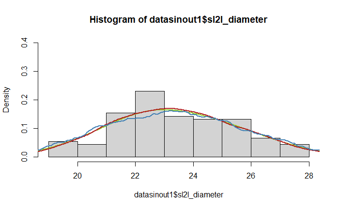

```r
lines(density(datasinout1$sl2l_diameter,kernel = "epanechnikov",width=h1),col="firebrick",lwd=2)
lines(density(datasinout1$sl2l_diameter,kernel = "rectangular",width=h1),col="steelblue",lwd=2)
```

```r
h1<-h_sil4
# la función density es la estimación
hist(datasinout1$sl2l_diameter, freq = FALSE,ylim=c(0,0.4))
lines(density(datasinout1$sl2l_diameter,kernel = "gaussian",width=h1),col="yellowgreen",lwd=2)
```

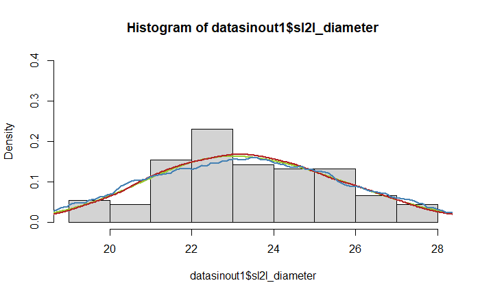

```r
lines(density(datasinout1$sl2l_diameter,kernel = "epanechnikov",width=h1),col="firebrick",lwd=2)
lines(density(datasinout1$sl2l_diameter,kernel = "rectangular",width=h1),col="steelblue",lwd=2)
```

bw.nrd0 = El valor predeterminado es 0,9 veces el mínimo de la desviación estándar y el rango intercuartil dividido por 1,34 veces el tamaño de la muestra elevado a la quinta potencia negativa (= ‘regla general’ de Silverman, Silverman (1986, página 48, ecuación (3.31)) ) a menos que coincidan los cuartiles cuando se garantizará un resultado positivo.

```r
#con otra funcion
bw.nrd(datos$sl2l_dm)
```

```
[1] 1.016634
```

```r
bw.nrd0(datos$sl2l_dm)
```

```
[1] 0.8631801
```

```r
bw.nrd(datasinout1$sl2l_diameter)
```

```
[1] 0.8606322
```

```r
bw.nrd0(datasinout1$sl2l_diameter)
```

```
[1] 0.7307254
```

```r
# Estimadores basados en nucleos

# Estimacion Parzen
uniforme<-function(u)
{
  ifelse(u>-1 & u<1,1,0)/2  # es mi indicadora y mi calcula el nucleo uniforme
}

#para nucleos
f_sombrero<-function(x,k,datos,h) #datos= Xi
{
  s<-0
  for(i in 1:length(datos))
  {
    c<-k((x-datos[i])/h)
    s<-s+c
  }
  f<-s/(length(datos)*h)
  return(f)
}

# Otros nucleos
epa<-function(u)
{
  ifelse(abs(u) < 1,3/4*(1-u^2),0)
}

densidad.est.parzen<-function(x,h,z) # x: datos, z:valor donde exaluo la f
{
  f_sombrero(z,uniforme,x,h)
}
```

```r
#ventana de CV (Convalidaci´on Cruzada por M´axima Verosimilitud)
# primero veamos como funciona el calculo del segundo termino

i<-1
h<-3
f.hat<-c()
for(i in 1:length(datos$sl2l_dm))
{
  f.hat[i]<-f_sombrero(datos$sl2l_dm[i],epa,datos=datos$sl2l_dm[-i],h)
}

# para un h fijo, el segundo termino de LSCV(h)
2*mean(f.hat)

# ventana con LSCV (leave-one-out-Cross-Validation)

lscv<-function(datos,k, h)
{
  f.hat.x<-c()
  for(i in 1:length(datos))
  {
    f.hat.x[i]<-f_sombrero(datos[i],k,datos[-i],h)
  }
  LSCV<-integrate(Vectorize(f_sombrero,"x"),lower=-Inf,upper=Inf,k=k,datos=datos,h=h)$value-2*mean(f.hat.x)
  return(LSCV)
}

h<-seq(10,28,1) # si la ventana es muy chiquita se queja...se queja por todo el integrate...

LSCV_h<-c()
for(j in 1:length(h))
{
  LSCV_h[j]<-lscv(datos$sl2l_dm,epa,h[j])
}

plot(h,LSCV_h,type="l") #pasa que para muchas ventanas no encontró datos...no las tengo en cuenta
plot(h[2:6],LSCV_h[2:6],type = "l")
h[which.max(LSCV_h)]
```

[output not shown]

```r
mledist()
```

```r
data$sl2l_diameter[2]
```

```
[1] 21.3498
```

```r
est_mom
```

```
[1] 92.3704
```

#### Cota de Rao-Cramer - Estimadores Insesgados

Buscamos el límite o el que se aproxima a la cota Rao-Cramer. Esto incluye al indice fisher.

El indice fisher mide la curvatura de aquello que me lleva al estimador

```r
help(crb)
```

```
No documentation for ‘crb’ in specified packages and libraries:
you could try ‘??crb’
```

```r
CRB(sdf=c(f1, f2))
```

```
$CRLB
           [,1]     [,2]
[1,]  0.6669675 14.00166
[2,] 15.0016601  0.50000

$FIM
         [,1]    [,2] [,3] [,4]
[1,] 1.499323 0.00000    0    0
[2,] 0.000000 1.07142    1    0
[3,] 0.000000 1.00000    1    0
[4,] 0.000000 0.00000    0    2

$EMD
[1] 29.00332
```

```r
library(fastDummies)
library(sjPlot)
library (Rcpp)

tab_model(Rg1,show.est=TRUE,show.se=TRUE,show.std=TRUE,show.df=TRUE,show.p=TRUE,show.fstat=TRUE,digits=2,title="Resumen del modelo",p.style="numeric_stars")
```

[output not shown]